# NC 2026 Primary: Unaffiliated Voter Ballot Choice by County

Which party ballot did unaffiliated voters choose?

Published

March 9, 2026

## Data

The number of unaffiliated voters in North Carolina has been steadily growing, raising the question of how likely these voters are to disrupt voting patterns and electoral outcomes in the state. Because North Carolina has semi-closed primaries, unaffiliated voters can choose which primary they want to vote in by requesting either the Democratic or Republican ballot. While some voters may make strategic choices — for example, an unaffiliated voter who leans Democratic picking the Republican ballot to support the candidate least likely to win the general election — this number is likely small. Examining ballot choice in primaries is therefore a useful starting point for understanding the inclinations of unaffiliated voters. Here, I provide a first cut by looking at whether ballot choice is related to the partisan leaning of NC counties.

In the March 3, 2026 primary, **215,488** unaffiliated voters cast either a Democratic or Republican ballot. Statewide, **56.1%** chose the Democratic ballot and **43.9%** chose the Republican ballot.

## Percent Choosing the Democratic Ballot

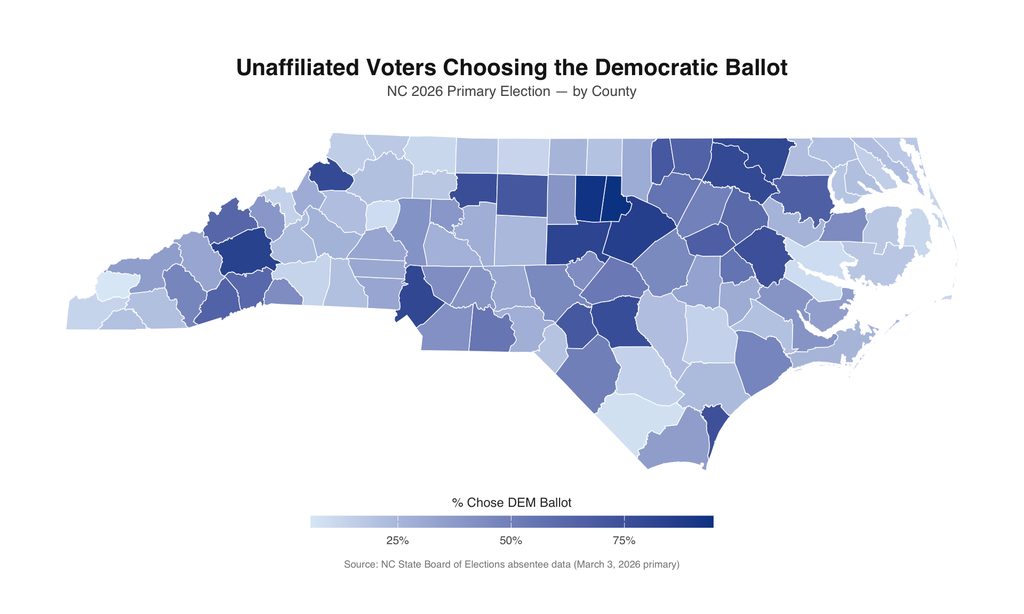

## Percent Choosing the Republican Ballot

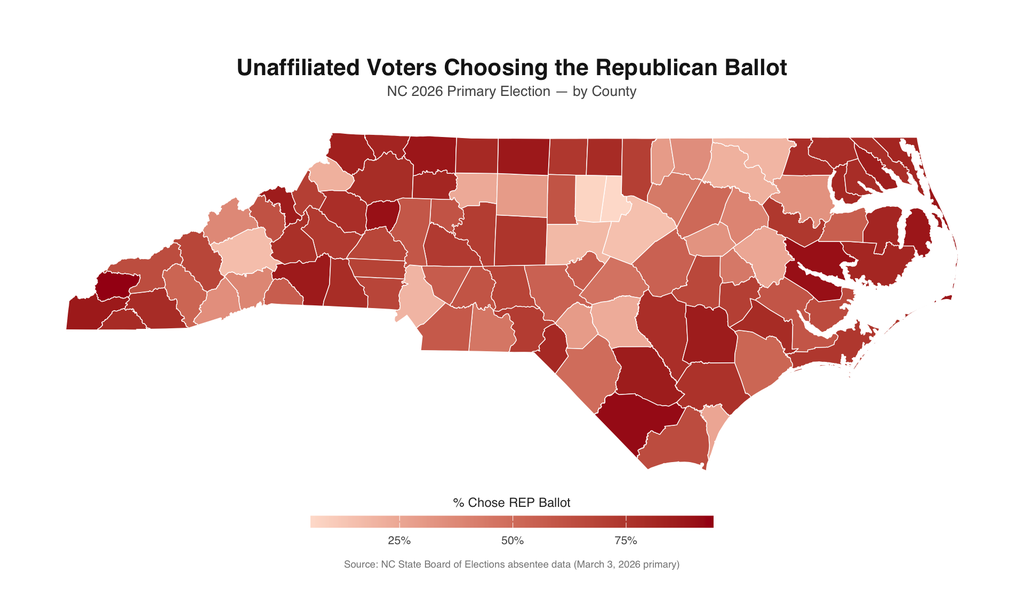

## Democratic vs Republican Margin

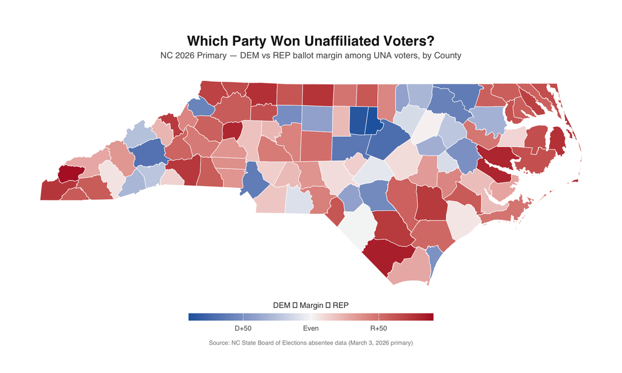

## Counties with the Highest Percent Choosing the Democratic Ballot

| County | UNA Voters | DEM % | REP % |
| --- | --- | --- | --- |
| DURHAM | 9,290 | 94.5% | 5.5% |
| ORANGE | 5,108 | 93.0% | 7.0% |
| WAKE | 24,265 | 85.3% | 14.7% |
| BUNCOMBE | 11,823 | 83.8% | 16.2% |
| CHATHAM | 3,409 | 82.4% | 17.6% |
| NORTHAMPTON | 393 | 80.9% | 19.1% |
| MECKLENBURG | 17,069 | 80.7% | 19.3% |
| HALIFAX | 888 | 79.3% | 20.7% |
| WATAUGA | 1,522 | 78.9% | 21.1% |
| CUMBERLAND | 3,481 | 76.9% | 23.1% |

## Counties with the Highest Percent Choosing the Republican Ballot

| County | UNA Voters | DEM % | REP % |
| --- | --- | --- | --- |
| GRAHAM | 342 | 5.8% | 94.2% |
| COLUMBUS | 1,151 | 8.3% | 91.7% |
| BEAUFORT | 1,669 | 9.5% | 90.5% |
| ALEXANDER | 964 | 9.8% | 90.2% |
| SURRY | 2,627 | 11.8% | 88.2% |
| DARE | 2,015 | 11.9% | 88.1% |
| ROCKINGHAM | 3,092 | 12.4% | 87.6% |
| CHEROKEE | 775 | 12.8% | 87.2% |
| RUTHERFORD | 1,913 | 13.3% | 86.7% |
| BLADEN | 874 | 13.7% | 86.3% |

## Do Unaffiliated Voters Align With Their County?

To test whether unaffiliated voters’ ballot choices track the partisan lean of their county, I merge the 2026 primary ballot data with the 2024 presidential two-party vote share by county.

### Trump Vote Share vs. % Unaffiliated Choosing the Democratic Ballot

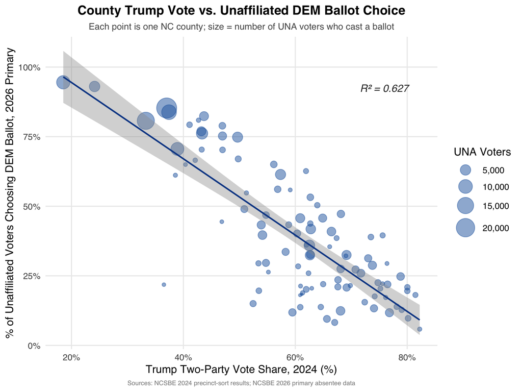

In counties where Trump ran strongest, unaffiliated voters overwhelmingly chose the Republican primary ballot. The relationship is strongly negative (R = -.80).

### Trump Vote Share vs. % Unaffiliated Choosing the Republican Ballot

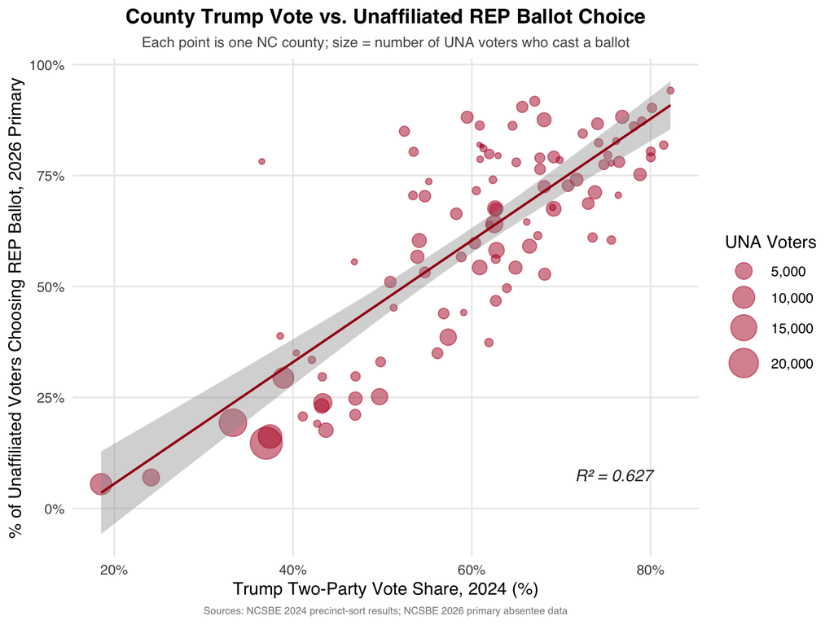

The mirror image: unaffiliated voters in Trump-heavy counties chose the Republican ballot at very high rates (R=.80). (The two R values are identical because % DEM and % REP are complements).

### Combined View: UNA Ballot Margin vs. County Partisan Lean

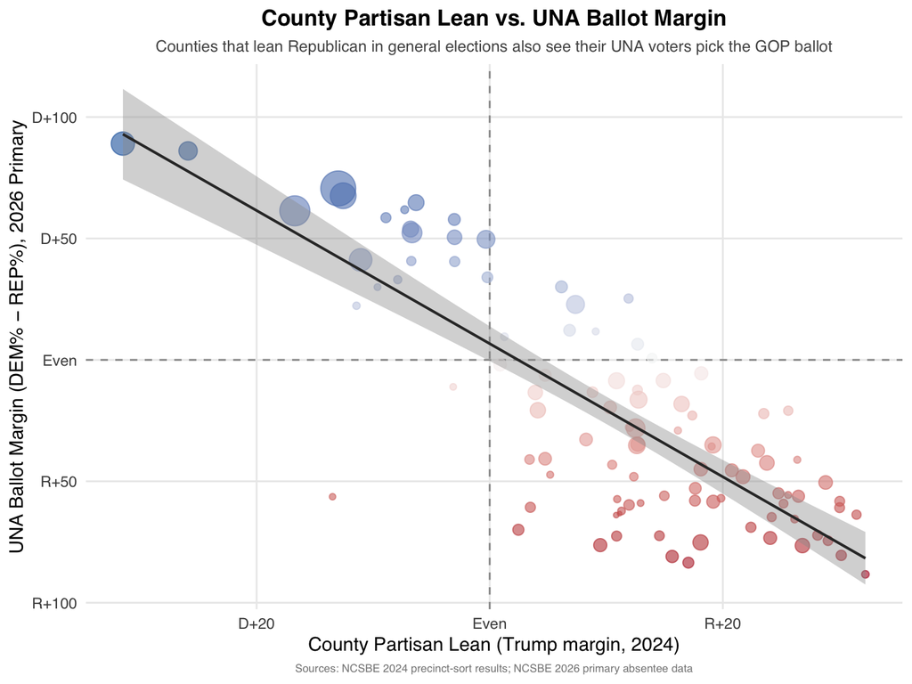

This plot shows the same relationship on a margin-vs-margin scale: counties in the lower-right (Republican-leaning counties where UNA voters picked Republican ballots) and upper-left (Democratic counties where UNA voters picked Democratic ballots) confirm that unaffiliated voters broadly follow their county’s partisan lean.